# Appendix A - Abrolhos Marine Park Western Rock Lobster Report

Yamatji Shallow Bank, 2025 and 2026 pot surveys

## Survey effort

Summary of western rock lobster pot sampling on Yamatji Shallow Bank in the 2025 and 2026 surveys, showing the number of pots deployed, the number of pots that fished successfully and were counted, and the number of lobsters measured in each management zone. NPZ = National Park Zone (no take), SPZ = Special Purpose Zone (open to commercial and recreational fishing). Pots that were lost, had a missing trap door, or were flagged in the field as not countable are deployed but not counted.

| Year | Zone | Pots deployed | Pots counted | Lobsters measured |
| --- | --- | --- | --- | --- |
| 2025 | National Park Zone | 55 | 54 | 273 |
| 2025 | Special Purpose Zone | 93 | 91 | 483 |
| 2026 | National Park Zone | 55 | 53 | 124 |
| 2026 | Special Purpose Zone | 84 | 83 | 248 |

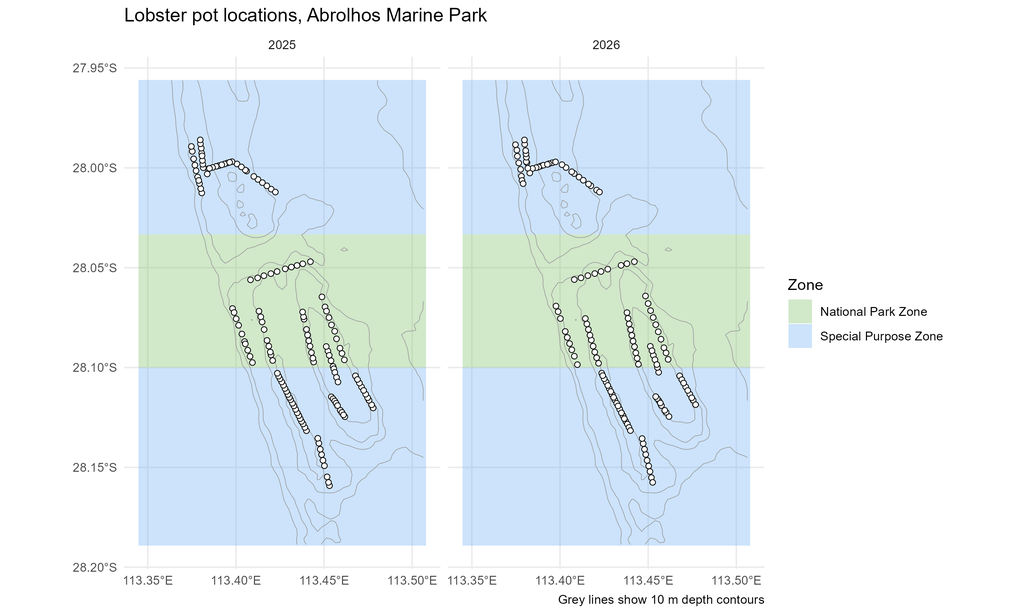

Locations of lobster pots on Yamatji Shallow Bank, shown separately for the 2025 and 2026 surveys. Commonwealth marine park zone boundaries and 10 m depth contours are shown. ABMP = Abrolhos Marine Park (Commonwealth).

## Abundance

Western rock lobster catch rates by zone and survey year, showing the number of pots counted, the total number of lobsters caught, and the mean and standard error of the number of lobsters per pot for all lobsters and for legal sized lobsters. Pots that caught no lobsters are included as zeros. Catch is reported per pot rather than per pot-hour because set times were not recorded in 2026.

| Year | Zone | Pots | Total lobsters | Mean per pot | SE | Mean legal per pot | SE legal |
| --- | --- | --- | --- | --- | --- | --- | --- |
| 2025 | National Park Zone | 54 | 261 | 4.83 | 0.77 | 4.09 | 0.57 |
| 2025 | Special Purpose Zone | 91 | 471 | 5.18 | 0.71 | 3.13 | 0.43 |
| 2026 | National Park Zone | 53 | 124 | 2.34 | 0.45 | 1.72 | 0.35 |
| 2026 | Special Purpose Zone | 83 | 248 | 2.99 | 0.58 | 0.94 | 0.19 |

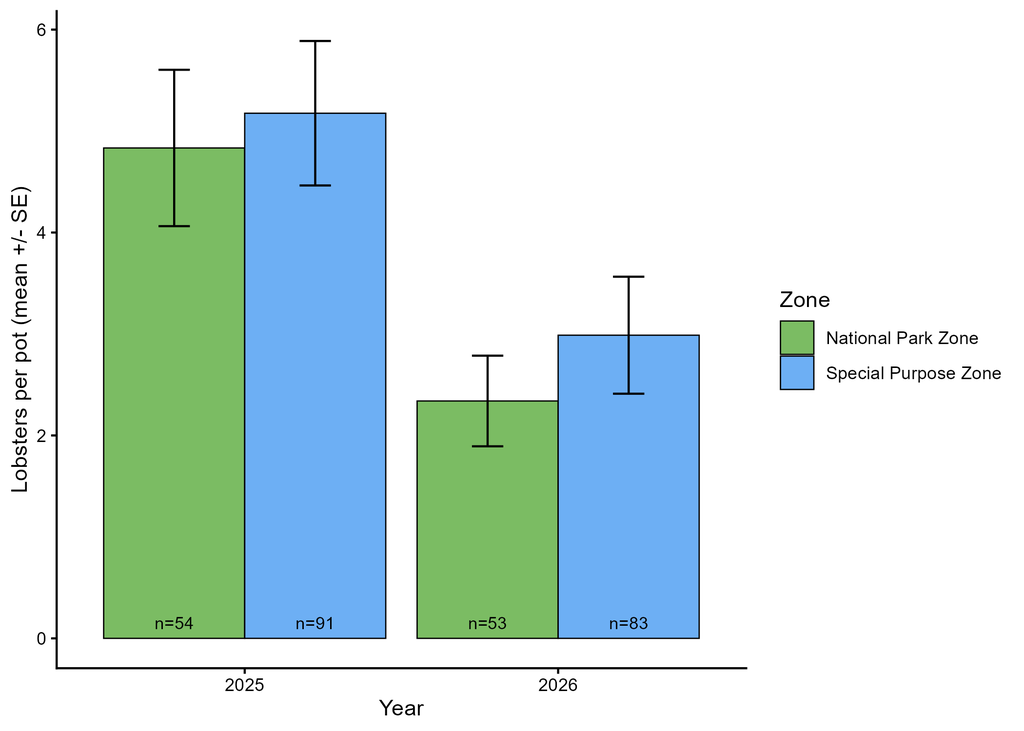

Western rock lobster catch rate (mean number of lobsters per pot, +/- standard error) by management zone and survey year, from pot sampling on Yamatji Shallow Bank. Sample sizes are the number of pots counted in each zone and year. Pots that caught no lobsters are included as zeros.

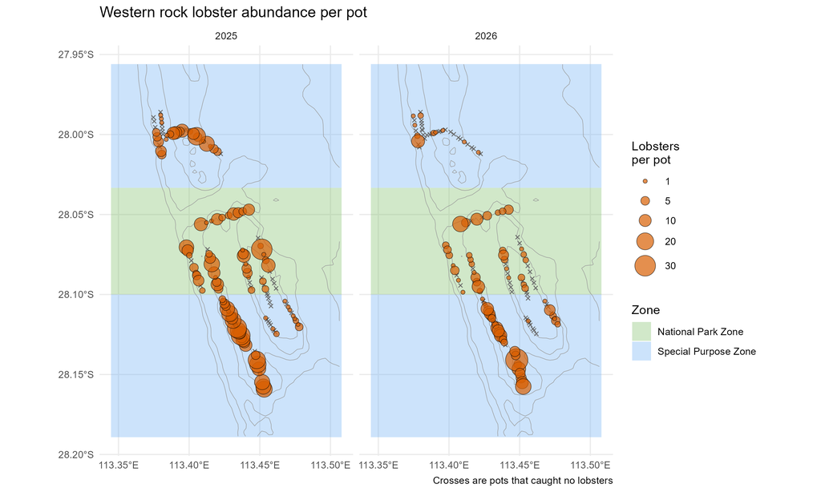

Spatial distribution of total western rock lobster abundance per pot, shown separately for the 2025 and 2026 surveys. Symbol size is scaled to the number of lobsters caught and crosses mark pots that caught no lobsters. Commonwealth marine park zone boundaries are shown.

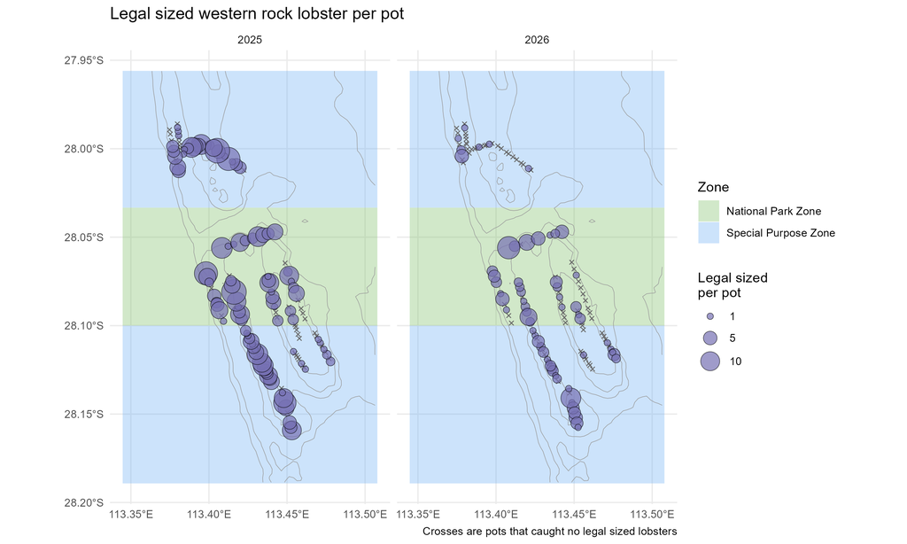

Spatial distribution of legal sized western rock lobster abundance per pot, shown separately for the 2025 and 2026 surveys. Symbol size is scaled to the number of legal sized lobsters caught. Legal size is a carapace length greater than 76 mm. Commonwealth marine park zone boundaries are shown.

## Size structure

Summary of western rock lobster carapace length by zone and survey year, showing the number of lobsters measured, the mean, median, minimum and maximum carapace length, and the percentage of measured lobsters above the legal minimum size. The minimum legal carapace length for western rock lobster is 76 mm.

| Year | Zone | n | Mean length (mm) | Median (mm) | Min | Max | % legal |
| --- | --- | --- | --- | --- | --- | --- | --- |
| 2025 | National Park Zone | 273 | 92.7 | 93 | 24.0 | 129.0 | 85.0 |
| 2025 | Special Purpose Zone | 483 | 81.6 | 82 | 50.0 | 129.0 | 60.7 |
| 2026 | National Park Zone | 124 | 86.6 | 90 | 51.0 | 120.0 | 73.4 |
| 2026 | Special Purpose Zone | 248 | 73.0 | 72 | 50.3 | 125.5 | 31.5 |

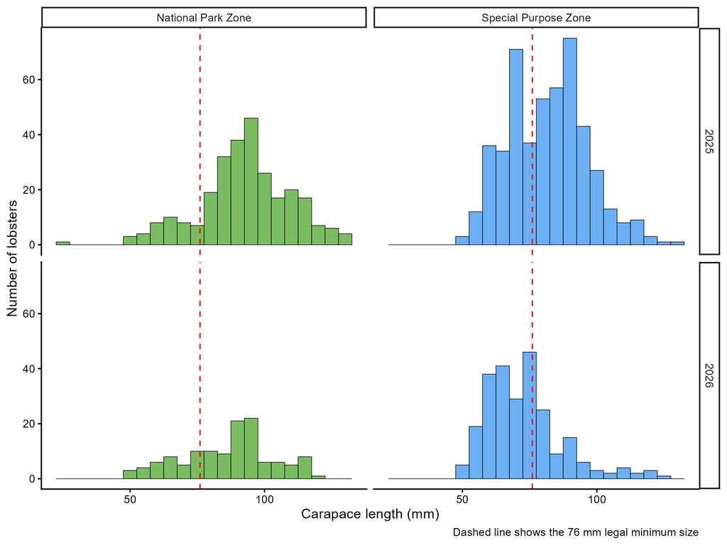

Carapace length frequency distribution of western rock lobster by management zone (columns) and survey year (rows), from pot sampling on Yamatji Shallow Bank. Bars are counts of lobsters in 5 mm length bins. The dashed red line shows the 76 mm legal minimum size.

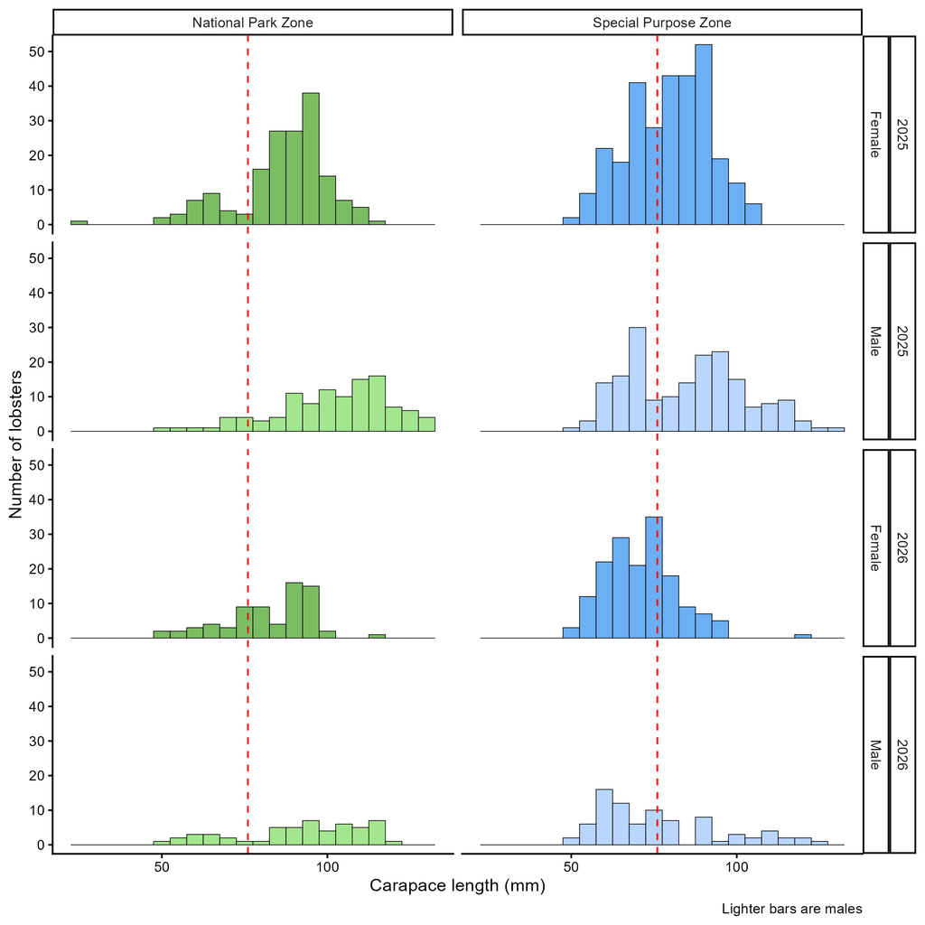

Carapace length frequency distribution of western rock lobster by management zone (columns), survey year and sex (rows), from pot sampling on Yamatji Shallow Bank. Bars are counts of lobsters in 5 mm length bins, with zone setting the colour and sex the shade, and males shown as the lighter bars. Lobsters whose sex was not recorded are excluded. The dashed red line shows the 76 mm legal minimum size.

### Standardised size distributions

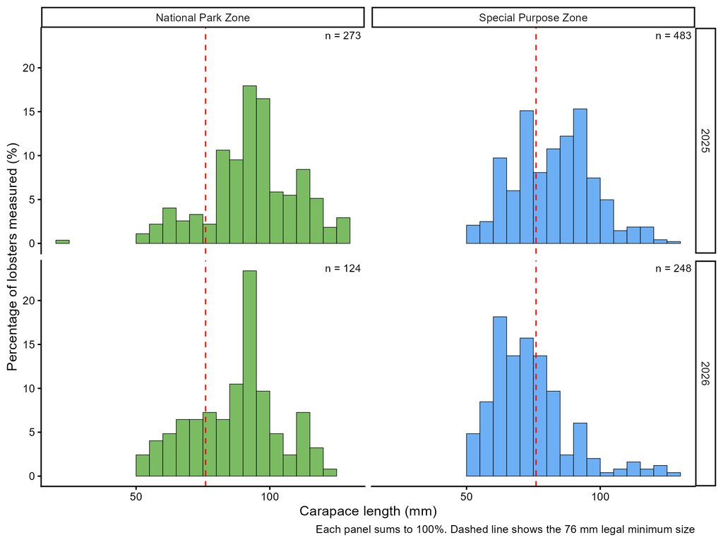

Standardised carapace length frequency distribution of western rock lobster by management zone (columns) and survey year (rows), from pot sampling on Yamatji Shallow Bank. Each panel is scaled to sum to 100% so that the shape of the size distribution can be compared independently of the number of lobsters caught. Sample sizes are given in each panel, as percentages from a small sample are considerably noisier. The dashed red line shows the 76 mm legal minimum size.

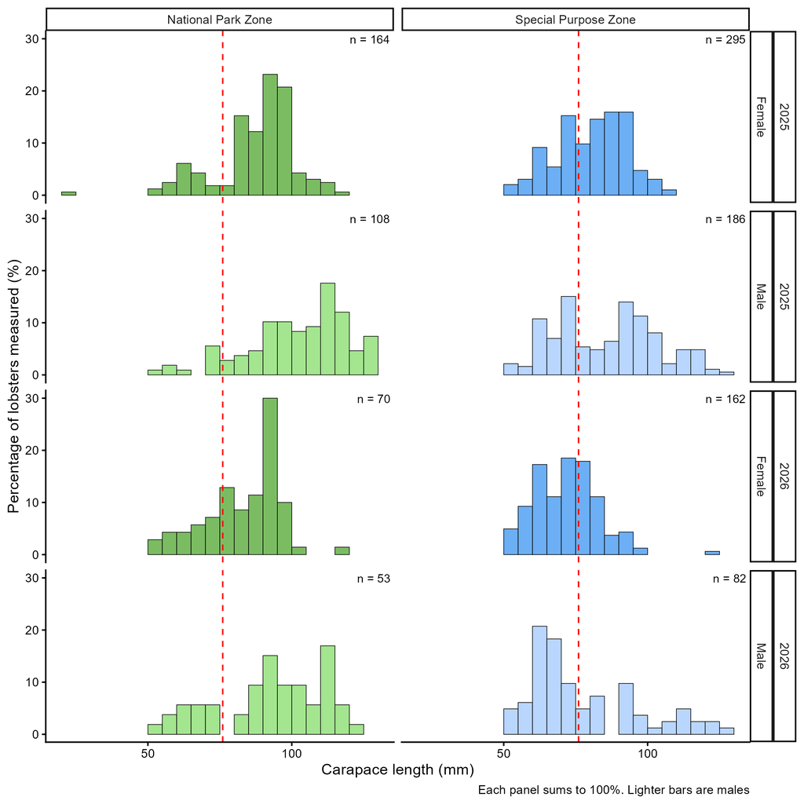

Standardised carapace length frequency distribution of western rock lobster by management zone (columns), survey year and sex (rows), from pot sampling on Yamatji Shallow Bank. Each panel is scaled to sum to 100%, with zone setting the colour and sex the shade, and males shown as the lighter bars. Sample sizes are given in each panel. Lobsters whose sex was not recorded are excluded. The dashed red line shows the 76 mm legal minimum size.

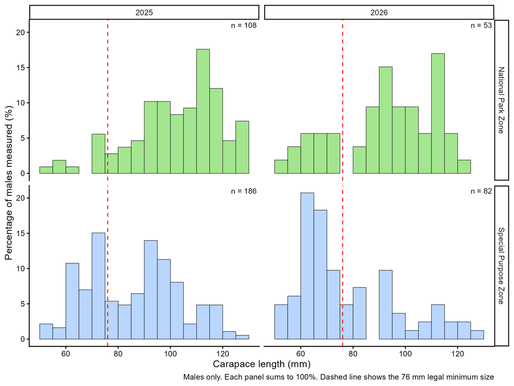

Standardised carapace length frequency distribution of male western rock lobster only, by survey year (columns) and management zone (rows), from pot sampling on Yamatji Shallow Bank. Each panel is scaled to sum to 100%, with the two zones stacked within each year so that their size distributions can be compared directly. Sample sizes are given in each panel. The dashed red line shows the 76 mm legal minimum size.

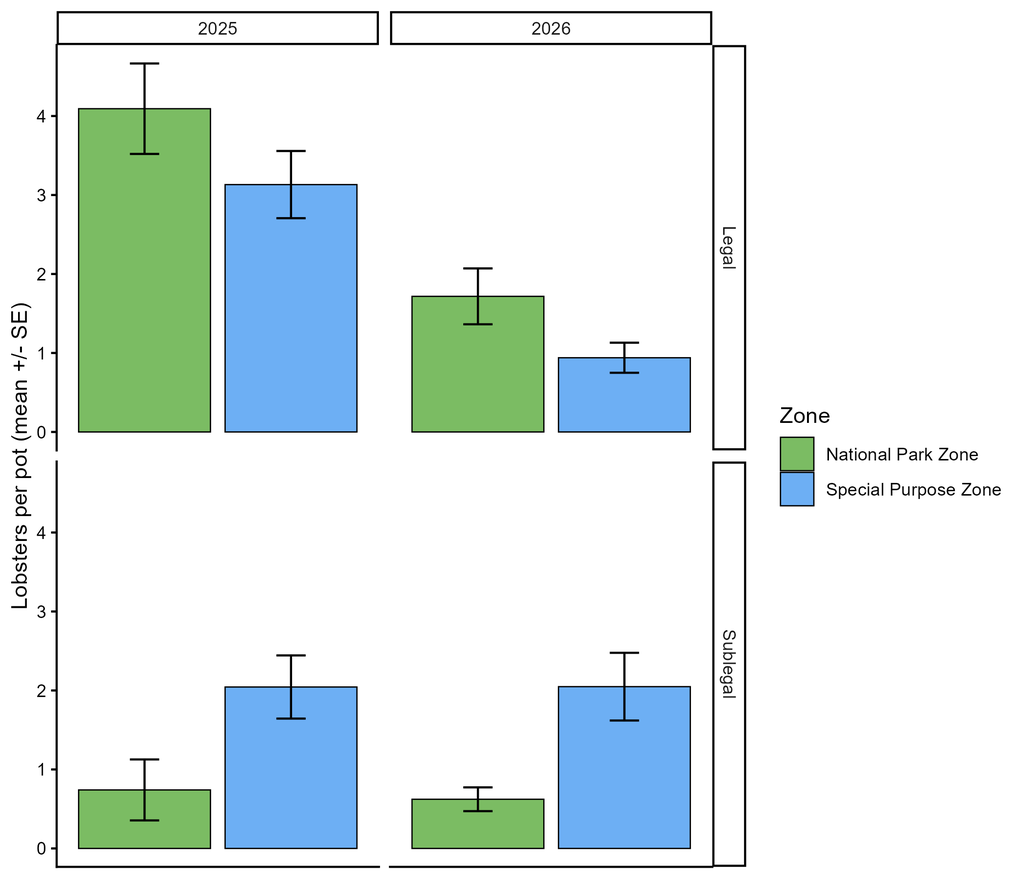

Legal and sublegal western rock lobster catch rate (mean number of lobsters per pot, +/- standard error) by management zone (bars) and survey year (columns), from pot sampling on Yamatji Shallow Bank. Legal size is a carapace length greater than 76 mm. Pots that caught no lobsters are included as zeros.

## Modelling: catch inside vs outside the National Park Zone

Catch per pot was modelled with a negative binomial generalised linear mixed model (log link), fitted in `glmmTMB`:

`catch ~ status * year + depth_z + (1 | string)`

where `status` is inside or outside the National Park Zone, `year` is a factor, `depth_z` is pot depth standardised to zero mean and unit variance, and `string` is the line of pots that each pot belonged to. Predicted means and standard errors for each status-by-year combination were obtained with `emmeans`, holding depth at its mean.

Pots were set in strings of roughly 8 to 20 pots, and the same 14 strings were fished in both survey years. Individual pots were not dropped in exactly the same positions each year, so the `(1 | string)` term acts as the spatial pairing that makes the between-year comparison like for like. It is not a claim that a string is a biologically coherent unit: a long string spans several kilometres, so its two ends are not interchangeable. Because year is compared within strings its standard error is reduced, while status is compared almost entirely between strings and its standard error is roughly doubled relative to a model fitted without the term.

The specification was originally a Tweedie model. Tweedie could not be fitted to the two sparsest responses once the random effect was included: legal males and large males both terminated with a non-positive-definite Hessian and no usable standard errors, and the large male string variance diverged, giving predictions several times the observed means. The Tweedie power parameter is weakly identified against the random effect variance when the response is mostly zeros, which is the case for large males (74% of counted pots caught none). The negative binomial has no such parameter, fits all six responses cleanly, and is the conventional choice for integer counts.

Six responses were modelled with this specification: legal catch, sublegal catch, legal males, legal females, males of 100 mm or more, and all lobsters combined. These are not independent tests of each other. Legal male and legal female catch together make up the legal catch, apart from 3 legal animals whose sex was not recorded; the large males are a subset of the legal males (137 of 281); and the all lobsters response is the legal and sublegal responses added together.

**Status is spatially confounded with survey area.** The National Park Zone is a single contiguous block that was fished on its own day in both years. Comparing inside with outside is therefore partly comparing the middle area with the northern and southern areas, and any habitat difference between those areas is not separable from the effect of protection.

Predicted western rock lobster catch per pot from the negative binomial generalised linear mixed model, by size class, zoning status and survey year, with standard errors and asymptotic 95% confidence limits. Predictions are made with depth held at its mean. NPZ = National Park Zone.

| Size class | Status | Year | Per pot | SE | Lower CL | Upper CL |
| --- | --- | --- | --- | --- | --- | --- |
| Legal | Outside NPZ | 2025 | 1.88 | 0.61 | 1.00 | 3.54 |
| Legal | Inside NPZ | 2025 | 4.16 | 1.53 | 2.02 | 8.55 |
| Legal | Outside NPZ | 2026 | 0.53 | 0.18 | 0.27 | 1.04 |
| Legal | Inside NPZ | 2026 | 1.64 | 0.61 | 0.78 | 3.42 |
| Sublegal | Outside NPZ | 2025 | 0.54 | 0.28 | 0.20 | 1.48 |
| Sublegal | Inside NPZ | 2025 | 0.49 | 0.30 | 0.15 | 1.61 |
| Sublegal | Outside NPZ | 2026 | 0.53 | 0.27 | 0.19 | 1.46 |
| Sublegal | Inside NPZ | 2026 | 0.54 | 0.33 | 0.17 | 1.77 |
| Legal male | Outside NPZ | 2025 | 0.76 | 0.24 | 0.40 | 1.43 |
| Legal male | Inside NPZ | 2025 | 1.58 | 0.56 | 0.80 | 3.15 |
| Legal male | Outside NPZ | 2026 | 0.21 | 0.08 | 0.10 | 0.44 |
| Legal male | Inside NPZ | 2026 | 0.77 | 0.28 | 0.37 | 1.58 |
| Legal female | Outside NPZ | 2025 | 1.23 | 0.41 | 0.63 | 2.37 |
| Legal female | Inside NPZ | 2025 | 2.13 | 0.82 | 1.00 | 4.52 |
| Legal female | Outside NPZ | 2026 | 0.35 | 0.13 | 0.17 | 0.73 |
| Legal female | Inside NPZ | 2026 | 0.74 | 0.30 | 0.33 | 1.63 |
| Male 100 mm+ | Outside NPZ | 2025 | 0.34 | 0.10 | 0.19 | 0.62 |
| Male 100 mm+ | Inside NPZ | 2025 | 0.96 | 0.28 | 0.54 | 1.70 |
| Male 100 mm+ | Outside NPZ | 2026 | 0.12 | 0.05 | 0.06 | 0.26 |
| Male 100 mm+ | Inside NPZ | 2026 | 0.36 | 0.12 | 0.18 | 0.69 |
| All lobsters | Outside NPZ | 2025 | 2.30 | 0.88 | 1.09 | 4.88 |
| All lobsters | Inside NPZ | 2025 | 5.70 | 2.52 | 2.39 | 13.58 |
| All lobsters | Outside NPZ | 2026 | 1.07 | 0.43 | 0.49 | 2.34 |
| All lobsters | Inside NPZ | 2026 | 2.64 | 1.17 | 1.10 | 6.31 |

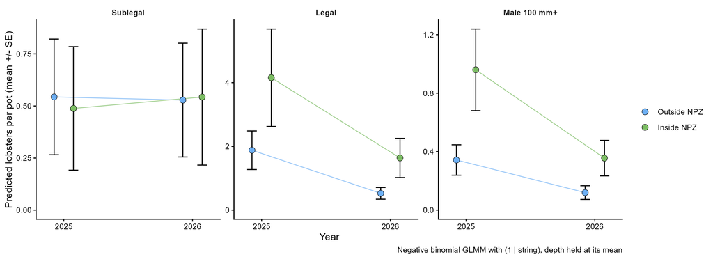

Predicted western rock lobster catch per pot inside and outside the National Park Zone across the size progression from sublegal to legal to large males, from the negative binomial generalised linear mixed model. Points are predicted means with standard errors, with depth held at its mean. Note that each panel has its own y axis scale. Legal size is a carapace length greater than 76 mm. NPZ = National Park Zone.

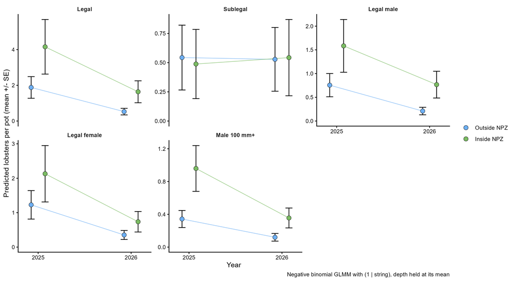

Predicted western rock lobster catch per pot inside and outside the National Park Zone for all five size class models, including legal males and legal females separately, from the negative binomial generalised linear mixed model. Points are predicted means with standard errors, with depth held at its mean. Note that each panel has its own y axis scale. NPZ = National Park Zone.

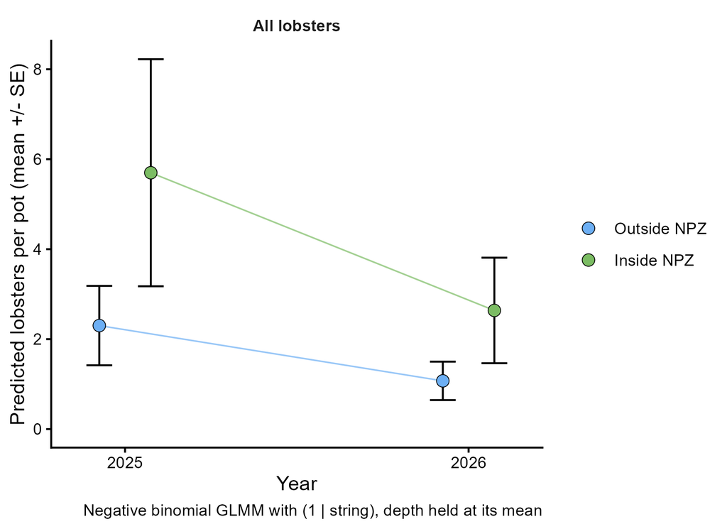

Predicted total western rock lobster catch per pot, legal and sublegal combined, inside and outside the National Park Zone, from the negative binomial generalised linear mixed model. Points are predicted means with standard errors, with depth held at its mean. This response is the sum of the legal and sublegal responses shown above rather than an independent size class. NPZ = National Park Zone.

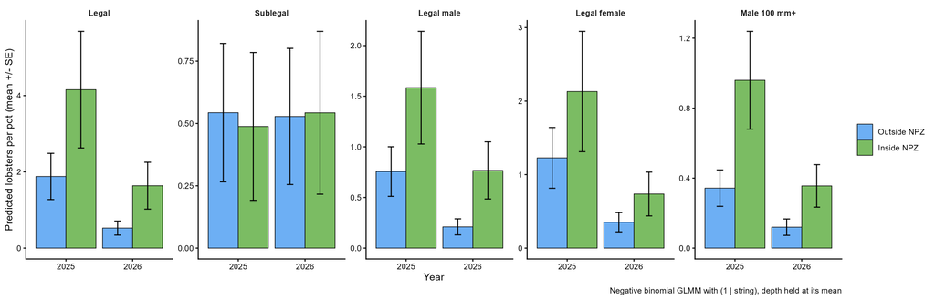

Predicted western rock lobster catch per pot inside and outside the National Park Zone by size class and survey year, from the negative binomial generalised linear mixed model, shown as bars with standard errors. Depth is held at its mean and each panel has its own y axis scale. NPZ = National Park Zone.

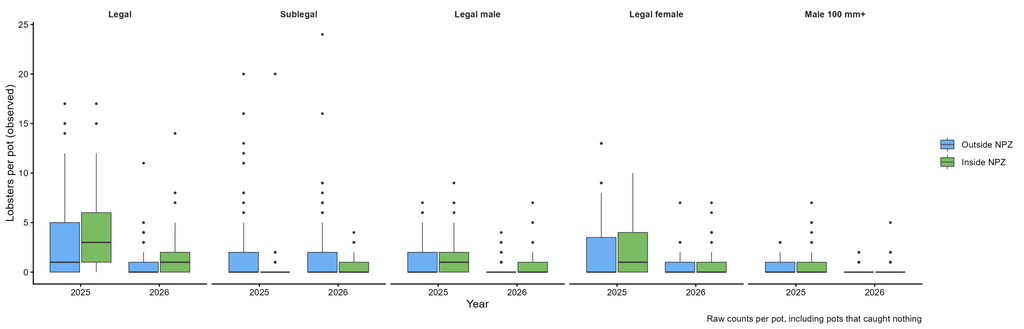

Observed western rock lobster catch per pot by size class, zoning status and survey year, showing the spread of the raw counts behind the modelled means. Boxes show the median and interquartile range with whiskers to 1.5 times the interquartile range. All panels share a y axis so that size classes can be compared against each other. Pots that caught no lobsters are included as zeros. NPZ = National Park Zone.

Coefficients of the negative binomial generalised linear mixed model of western rock lobster catch per pot, on the log scale, with standard errors, z statistics and p values. Reference levels are outside the National Park Zone in 2025, so the status term is the effect of protection in 2025 and the interaction term is the change in that effect by 2026. NPZ = National Park Zone.

| Size class | Term | Estimate | SE | z | p |
| --- | --- | --- | --- | --- | --- |
| Legal | (Intercept) | 0.631 | 0.322 | 1.96 | 0.050 |
| Legal | statusInside NPZ | 0.793 | 0.490 | 1.62 | 0.106 |
| Legal | year2026 | -1.273 | 0.225 | -5.66 | <0.001 |
| Legal | depth_z | 0.117 | 0.178 | 0.66 | 0.511 |
| Legal | statusInside NPZ:year2026 | 0.342 | 0.338 | 1.01 | 0.311 |
| Sublegal | (Intercept) | -0.610 | 0.511 | -1.19 | 0.233 |
| Sublegal | statusInside NPZ | -0.107 | 0.766 | -0.14 | 0.889 |
| Sublegal | year2026 | -0.028 | 0.257 | -0.11 | 0.912 |
| Sublegal | depth_z | -0.363 | 0.267 | -1.36 | 0.173 |
| Sublegal | statusInside NPZ:year2026 | 0.135 | 0.453 | 0.30 | 0.767 |
| Legal male | (Intercept) | -0.280 | 0.324 | -0.86 | 0.387 |
| Legal male | statusInside NPZ | 0.740 | 0.479 | 1.54 | 0.123 |
| Legal male | year2026 | -1.281 | 0.269 | -4.76 | <0.001 |
| Legal male | depth_z | 0.216 | 0.171 | 1.26 | 0.207 |
| Legal male | statusInside NPZ:year2026 | 0.556 | 0.383 | 1.45 | 0.147 |
| Legal female | (Intercept) | 0.205 | 0.337 | 0.61 | 0.542 |
| Legal female | statusInside NPZ | 0.551 | 0.507 | 1.09 | 0.277 |
| Legal female | year2026 | -1.248 | 0.255 | -4.90 | <0.001 |
| Legal female | depth_z | 0.143 | 0.209 | 0.69 | 0.493 |
| Legal female | statusInside NPZ:year2026 | 0.186 | 0.390 | 0.48 | 0.633 |
| Male 100 mm+ | (Intercept) | -1.070 | 0.304 | -3.53 | <0.001 |
| Male 100 mm+ | statusInside NPZ | 1.029 | 0.420 | 2.45 | 0.014 |
| Male 100 mm+ | year2026 | -1.052 | 0.383 | -2.75 | 0.006 |
| Male 100 mm+ | depth_z | 0.217 | 0.164 | 1.32 | 0.185 |
| Male 100 mm+ | statusInside NPZ:year2026 | 0.059 | 0.523 | 0.11 | 0.910 |
| All lobsters | (Intercept) | 0.834 | 0.383 | 2.17 | 0.030 |
| All lobsters | statusInside NPZ | 0.907 | 0.579 | 1.57 | 0.117 |
| All lobsters | year2026 | -0.764 | 0.210 | -3.64 | <0.001 |
| All lobsters | depth_z | -0.056 | 0.192 | -0.29 | 0.771 |
| All lobsters | statusInside NPZ:year2026 | -0.007 | 0.325 | -0.02 | 0.984 |

Likelihood ratio test of the status by year interaction for each size class, comparing the full model with an additive model in which the difference between zones is held constant across years. A significant result would indicate that the difference between zones changed between 2025 and 2026.

| Size class | Chi squared | df | p |
| --- | --- | --- | --- |
| Legal | 1.020 | 1 | 0.313 |
| Sublegal | 0.088 | 1 | 0.766 |
| Legal male | 2.096 | 1 | 0.148 |
| Legal female | 0.227 | 1 | 0.633 |
| Male 100 mm+ | 0.013 | 1 | 0.910 |
| All lobsters | 0.000 | 1 | 0.984 |

## Data notes

- Pots that were lost, had a missing trap door, or were flagged in the field as not countable are excluded from catch rates but retained in the pot table.
- Neither survey export records a string identifier, and the 2026 pot numbering does not follow position along the line, so strings were assigned by hand from the deployment order and pot positions. A string is one physical line of pots and is kept whole: one string crosses the National Park Zone boundary and has not been split, so that it still represents a single deployment.
- Pots that caught no lobsters are carried through the analysis as zeros.
- Set times were not recorded in 2026, so soak time is available for 2025 only and catch is reported per pot rather than per pot-hour.
- 2026 includes six extra pots labelled `F3`, `F3-2` and `FIII`. These are kept as distinct pots rather than merged with the numbered pots.
- Three 2026 pots lost GPS fix on retrieval; corrected positions were read from the field comments.
- One 2026 pot was logged at 0 m depth, which is not a possible seabed depth here. It is treated as missing and drops from the models.
- Non-lobster catch from 2026 is written to a separate bycatch file and is not included in these results.
- One 2025 measurement of 24 mm (National Park Zone, pot 2) sits well below the next smallest lobster at 50 mm and is likely a data entry error. It has been retained pending confirmation.